# rangeMapper

#### rangeMapper

- home
- faq
- gui
- bibliography

#### Case studies

rangeMapper

A platform for the study of macroecology of life history traits

# *rangeMapper* Graphical User Interface

*rangeMapper* comes with a user-friendly platform-independent tcltk graphical user interface (GUI).

## Main graphical window

Once the package is loaded you can open the GUI by typing:  
`rangeMapper()`

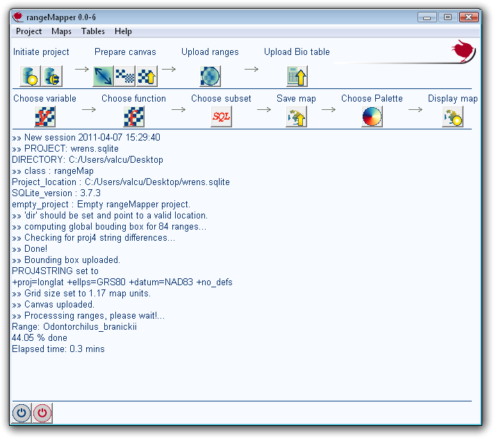

To quickly get started, work through all the steps from *Initiate project* to *Plot map* using the dataset and the range files which come together with the package (to find where they are located go to *Help/Example files*. Place the mouse over each button to get tool-tips. To get further help type *?rangeMapper* or *?* and the function name indicated by the tool-tip.

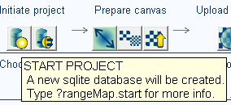

## rangeMapper step-by-step: project set-up

### Initiate/open project

For more information on the dataset type at the R prompter:  
`?wrens`  
`wrens`

After pushing the initiate project button, choose a location to save the file, name your new project, for example `wrens`, and press `OK`.

### Prepare canvas

Once the project has been initiated the next step is to prepare the canvas.  
The canvas is a regular grid of a given resolution (in map units) defined for the rectangular area (i.e. the global bounding box) encompassing all the ranges.

At this step, you have to:

- Push the `COMPUTE CANVAS EXTENT` button and then select all the range polygon files (*.shp format) in order to define the global bounding box of the project. The vector (*.shp) files for the wrens ranges data are stored in the package's directory. Access the `help/example files` menu to get the exact pathway for this directory.
- Push the `INPUT GRID SIZE` button and then input the desired resolution (a default value is provided). For the wrens, change the provided default of 125194.3m to a round 125000m.
- Push the `COMPUTE CANVAS` button to upload the canvas to the project's database.

### Process and upload ranges

At this step you can select a directory containing the range files. Then every range polygon is overlaid on the canvas and the result of the overlap is saved to the database.  
For the wrens, push the `PROCESS RANGES` button and select the directory with the wrens range vector files. Hit `YES` when asked to save range centroid and range extent data to the data project file.

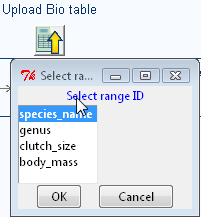

If you are only interested in species richness this step is optional. Data to be imported should be in .csv format (`;` separated!). However, any `data.frame` can be imported from the command line. See `?rangeMapper` for an example and `?bio.save` for more details. During the importing of the `BIO` table you will be prompted to choose the field,corresponding to the range file names. The `BIO` table should thus contain a column with the file names of the range polygons (without the file extension). This column is used to link data in the `BIO` table to the range polygons data. For the wrens example, push the `IMPORT BIO data` icon and select the `wrens.csv` data file stored in the package's directory (choose `Help/example` files to get the exact pathway to this file). Then select `species_name` as the ID to link the data with the range files. You are now ready to draw some maps!

## rangeMapper step-by-step: drawing maps

### Choose a variable

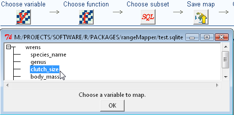

Once one or more `BIO` tables have been imported, the next step is choosing a variable (e.g. clutch size or body mass) to map. For the wrens example, push the `CHOOSE VARIABLE` icon and select `clutch size`.

### Choose or define a function

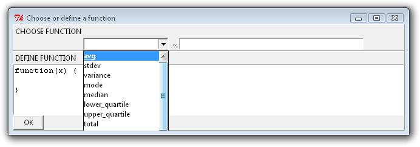

### Choose subsets

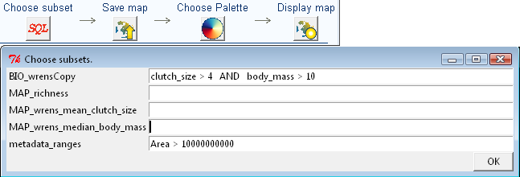

At this step you can select the data to be included in the `MAP`, based on the field values of any of the existing `BIO`, `MAP` or metadata_ranges tables. The subset strings used in the `Choose subsets` dialog should be valid `WHERE` SQL clauses. Since this step is optional for the running wrens example, skip this step and go to on.

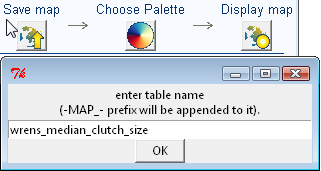

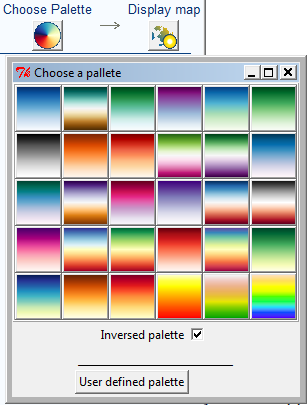

At this step you can choose one of the available color palettes . There is the option to inverse the color palette if needed. Aditionally an a user defined palette can be constructed. For the wrens example, push the `CHOOSE PALETTE` button and select or build the palette you like.

### Display a MAP

Once a color palette is chosen, a map of the active project can be selected and displayed on the default graphic device. The number of grouping intervals and the class intervals type can be set here. For more info on class intervals see *classInt* package.  
For the wrens, push the `DISPLAY MAP` button and accept the default value of 20 for the number of classes, and then select `equal` as the class interval type. Your map should be ready on the default graphical device.

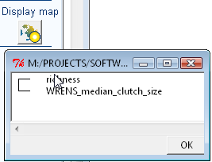

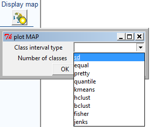

## Wrens mean coefficient of variation of body mass

Push the CHOOSE VARIABLE icon and select body mass. Then push the CHOOSE FUNCTION icon and type in the DEFINE FUNCTION BOX (between the curly brackets) the formula for coefficient of variation: “sd(x)/mean(x)” and then click OK. Save the map and display it .

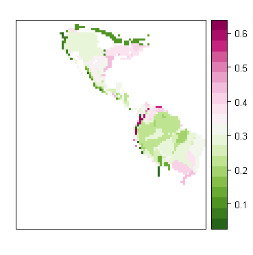